# Grafico borrado por MINSA, reconstruido con datos de 07/02/2022 - Fecha corte 05/02/2022

El MINSA borró el gráfico de barras apiladas que mostraba los muertos por COVID según estado de vacunación. Puede verse mas al respecto en este hilo https://twitter.com/gjrossir/status/1471474649678684174 Este script hace las cuentas para recrearlo

—> Bajar los archivos con get-data-minsa.bash

—> Download the files with get-data-minsa.bash

https://github.com/RonaldPeru007/covid-peru22/blob/master/get-data-minsa.bash

The Dataset used in this .Rmd file is from 07/02/2022

The Date 09/02/2021 used in this .Rmd is the start date of the vaccine campaign in Peru

The file 2022-02-07_grafico_borrado_x_MINSA.csv recreates the graph :

https://datawrapper.dwcdn.net/DSWWL/2/

```r
library(dplyr)
library(lubridate)
library(readr)
library(stringr)
library(ggplot2)
```

```r
cdc <-
    read_csv("../2022_02_07_TB_FALLECIDO_HOSP_VAC.csv") %>%
    mutate_at(vars(contains("fecha")), function(x){ as.Date(x, format="%d/%m/%Y") }) %>%
    mutate(semana_muerte = paste0(year(fecha_fallecimiento), "|", str_pad(week(fecha_fallecimiento), 2, pad="0")))
x <- cdc
```

```r
muertos <-
    x %>%
    filter(
        fecha_fallecimiento >= as.Date("09/02/2021","%d/%m/%Y"),
        # cdc_fallecido_covid > 0
    )
```

```r
resumen <-
    muertos %>%
    group_by(semana_muerte) %>%
    mutate(total_muertos_semana = n()) %>%
    summarise(
        no_vac = sum(if_else(flag_vacuna == 0, 1, 0)) ,
        una_vac = sum(if_else(flag_vacuna == 1, 1, 0)) ,
        dos_vac = sum(if_else(flag_vacuna == 2, 1, 0)) ,
        tres_vac = sum(if_else(flag_vacuna == 3, 1, 0)) ,
        total_muertos_semana = total_muertos_semana[1]
    ) %>%
    mutate(
        `No vacunado (%)` = no_vac/total_muertos_semana ,
        `1 vacuna (%)` = una_vac/total_muertos_semana ,
        `2 vacunas (%)` = dos_vac/total_muertos_semana ,
        `3 vacunas (%)` = tres_vac/total_muertos_semana ,
    )
```

Primera version para grafico de barras horizontal, no se vio tan bien

```r
hoy <- Sys.Date()
resumen %>% write_csv(paste0(hoy, "_", "muertos_vac_x_semana.csv"))
```

Segunda version con barras verticales, como el original

Creates the “2022-02-07_grafico_borrado_x_MINSA.csv” which recreates the daily chart MINSA doesn’t publish anymore since 24-12-2021…

https://datawrapper.dwcdn.net/DSWWL/2/

```r
transposed <-
    select(resumen, -no_vac, -una_vac, -dos_vac, -tres_vac, -total_muertos_semana) %>%
    # mutate(semana_muerte = as.character(as.integer(semana_muerte))) %>%
    mutate_at(vars(contains("%")), function(x) {round(x*100, 2)}) %>%
    t() %>%
    as.data.frame()

colnames(transposed) <- resumen$semana_muerte
transposed$estado_vacunacion <- rownames(transposed)
rownames(transposed) <- NULL
transposed %>%
    filter(estado_vacunacion != "semana_muerte") %>%
    # rename(estado_vacunacion = semana_muerte) %>%
    select(estado_vacunacion, everything()) %>%
    write_csv(paste0(hoy, "_", "grafico_borrado_x_MINSA.csv"))
```

Grafico exploratorio de criterios de fallecimiento, a primera vista no veo una diferencia en la prevalencia de criterios. Tal vez se viera por grupos de edad (como vi en niños). Hay que desarrollarlo mas

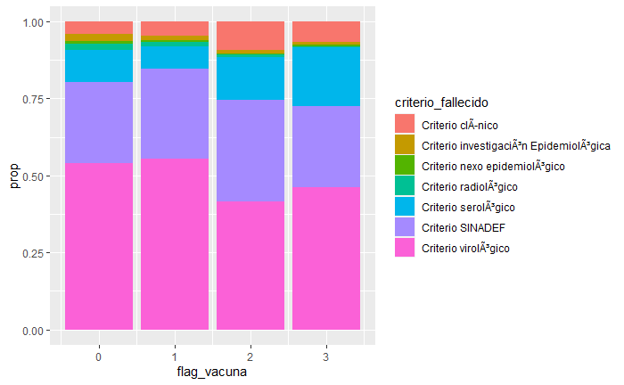

```r
# , eval=F, include=F

x %>%
    filter(year(fecha_fallecimiento) >= 2021) %>%
    count(flag_vacuna, criterio_fallecido,sort=T) %>%
    group_by(flag_vacuna) %>%
    mutate(total_criterio = sum(n)) %>%
    ungroup() %>%
    mutate(prop = n/total_criterio) %>%
    ggplot() +
    geom_col(aes(x=flag_vacuna, y=prop, fill=criterio_fallecido))
```